# IODS course project

Let’s standardize the dataset and print out summaries of the scaled data:

```r
boston_scaled <- scale(Boston)
summary(boston_scaled)
```

```
##       crim                 zn               indus
##  Min.   :-0.419367   Min.   :-0.48724   Min.   :-1.5563
##  1st Qu.:-0.410563   1st Qu.:-0.48724   1st Qu.:-0.8668
##  Median :-0.390280   Median :-0.48724   Median :-0.2109
##  Mean   : 0.000000   Mean   : 0.00000   Mean   : 0.0000
##  3rd Qu.: 0.007389   3rd Qu.: 0.04872   3rd Qu.: 1.0150
##  Max.   : 9.924110   Max.   : 3.80047   Max.   : 2.4202
##       chas              nox                rm               age
##  Min.   :-0.2723   Min.   :-1.4644   Min.   :-3.8764   Min.   :-2.3331
##  1st Qu.:-0.2723   1st Qu.:-0.9121   1st Qu.:-0.5681   1st Qu.:-0.8366
##  Median :-0.2723   Median :-0.1441   Median :-0.1084   Median : 0.3171
##  Mean   : 0.0000   Mean   : 0.0000   Mean   : 0.0000   Mean   : 0.0000
##  3rd Qu.:-0.2723   3rd Qu.: 0.5981   3rd Qu.: 0.4823   3rd Qu.: 0.9059
##  Max.   : 3.6648   Max.   : 2.7296   Max.   : 3.5515   Max.   : 1.1164
##       dis               rad               tax             ptratio
##  Min.   :-1.2658   Min.   :-0.9819   Min.   :-1.3127   Min.   :-2.7047
##  1st Qu.:-0.8049   1st Qu.:-0.6373   1st Qu.:-0.7668   1st Qu.:-0.4876
##  Median :-0.2790   Median :-0.5225   Median :-0.4642   Median : 0.2746
##  Mean   : 0.0000   Mean   : 0.0000   Mean   : 0.0000   Mean   : 0.0000
##  3rd Qu.: 0.6617   3rd Qu.: 1.6596   3rd Qu.: 1.5294   3rd Qu.: 0.8058
##  Max.   : 3.9566   Max.   : 1.6596   Max.   : 1.7964   Max.   : 1.6372
##      black             lstat              medv
##  Min.   :-3.9033   Min.   :-1.5296   Min.   :-1.9063
##  1st Qu.: 0.2049   1st Qu.:-0.7986   1st Qu.:-0.5989
##  Median : 0.3808   Median :-0.1811   Median :-0.1449
##  Mean   : 0.0000   Mean   : 0.0000   Mean   : 0.0000
##  3rd Qu.: 0.4332   3rd Qu.: 0.6024   3rd Qu.: 0.2683
##  Max.   : 0.4406   Max.   : 3.5453   Max.   : 2.9865
```

We can see that after standardizing the mean of each variable is zero.

```r
# create a quantile vector of crim
bins <- quantile(boston_scaled$crim)

# create a categorical variable 'crime'
crime <- cut(boston_scaled$crim, label = c("low", "med_low", "med_high", "high"), breaks = bins, include.lowest = TRUE)

# remove original crim from the dataset
boston_scaled <- dplyr::select(boston_scaled, -crim)

# add the new categorical value to scaled data
boston_scaled <- data.frame(boston_scaled, crime)

n <- nrow(boston_scaled)

# choose randomly 80% of the rows
ind <- sample(n,  size = n * 0.8)

# create train set
train <- boston_scaled[ind,]

# create test set
test <- boston_scaled[-ind,]
```

```r
# linear discriminant analysis
lda.fit <- lda(crime ~ ., data = train)

# print the lda.fit object
lda.fit
```

```
## Call:
## lda(crime ~ ., data = train)
##
## Prior probabilities of groups:
##       low   med_low  med_high      high
## 0.2425743 0.2524752 0.2475248 0.2574257
##
## Group means:
##                   zn      indus        chas        nox          rm
## low       1.01674100 -0.9410688 -0.07145661 -0.8896975  0.49014748
## med_low  -0.09819323 -0.3085810 -0.04073494 -0.5849641 -0.13304191
## med_high -0.38261997  0.2154877  0.12138096  0.4576804  0.08937387
## high     -0.48724019  1.0170690 -0.08304540  1.0664191 -0.43656799
##                 age        dis        rad        tax     ptratio
## low      -0.8720548  0.9174689 -0.7064735 -0.7366658 -0.46399005
## med_low  -0.3600396  0.3895195 -0.5551369 -0.4904482 -0.09448423
## med_high  0.3919199 -0.3817419 -0.3835199 -0.2625959 -0.33420407
## high      0.8068404 -0.8514661  1.6386213  1.5144083  0.78135074
##                black      lstat        medv
## low       0.38120312 -0.7979294  0.57159183
## med_low   0.35569069 -0.1432786  0.02276266
## med_high  0.06040612 -0.0419354  0.16376825
## high     -0.91883373  0.8744544 -0.69797457
##
## Coefficients of linear discriminants:
##                 LD1          LD2         LD3
## zn       0.10433545  0.758409517 -0.95194702
## indus   -0.03146331 -0.351665444  0.26860737
## chas    -0.08203879  0.027073433  0.10179736
## nox      0.38893126 -0.722916127 -1.29210759
## rm      -0.08391579 -0.045407589 -0.11190718
## age      0.24338106 -0.238086551 -0.17465631
## dis     -0.13268366 -0.293649469  0.22899287
## rad      2.95400260  0.923624321  0.03779446
## tax      0.03370673 -0.038238849  0.43396532
## ptratio  0.12431743  0.058818188 -0.28989280
## black   -0.14946439 -0.003148397  0.16625715
## lstat    0.17697443 -0.113281455  0.52616692
## medv     0.14811005 -0.349930841 -0.17307354
##
## Proportion of trace:
##    LD1    LD2    LD3
## 0.9444 0.0393 0.0162
```

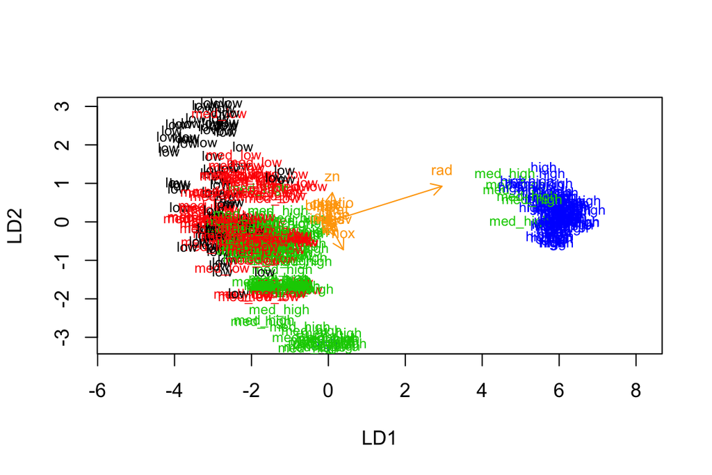

```r
# the function for lda biplot arrows
lda.arrows <- function(x, myscale = 1, arrow_heads = 0.1, color = "orange", tex = 0.75, choices = c(1,2)){
  heads <- coef(x)
  arrows(x0 = 0, y0 = 0,
         x1 = myscale * heads[,choices[1]],
         y1 = myscale * heads[,choices[2]], col=color, length = arrow_heads)
  text(myscale * heads[,choices], labels = row.names(heads),
       cex = tex, col=color, pos=3)
}

# target classes as numeric
classes <- as.numeric(train$crime)

# plot the lda results
plot(lda.fit, dimen = 2, col = classes, pch = classes)
lda.arrows(lda.fit, myscale = 1)
```

```r
# predict classes with test data
lda.pred <- predict(lda.fit, newdata = test)
```

You can check out my R script for the Data wrangling part [here](https://github.com/MikkoPatronen/IODS-project/blob/master/data/create_human.R).

# 5. Dimensionality reduction techniques

This week’s tasks present dimensionality reduction techniques. Principal Component Analysis (PCA) will be applied.

The R script file that created the data file can be viewed [here](https://github.com/MikkoPatronen/IODS-project/blob/master/data/create_human.R). Let us view information about the data:

## 5.1 Summary of the variables in the data:

```r
rm(list=ls())
library(dplyr)
library(ggplot2)
library(GGally)
library(tidyr)
library(MASS)
library(corrplot)
human <- read.table("human.txt")
str(human)
```

```
## 'data.frame':    155 obs. of  8 variables:
##  $ Edu2.FM  : num  0.198 0.931 0.861 0.977 0.989 ...
##  $ Labo.FM  : num  0.199 0.685 0.211 0.633 0.747 ...
##  $ Edu.Exp  : num  9.3 11.8 14 17.9 12.3 20.2 15.7 11.9 12.6 14.4 ...
##  $ Life.Exp : num  60.4 77.8 74.8 76.3 74.7 82.4 81.4 70.8 75.4 76.6 ...
##  $ GNI      : int  1885 9943 13054 22050 8124 42261 43869 16428 21336 38599 ...
##  $ Mat.Mor  : int  400 21 89 69 29 6 4 26 37 22 ...
##  $ Ado.Birth: num  86.8 15.3 10 54.4 27.1 12.1 4.1 40 28.5 13.8 ...
##  $ Parli.F  : num  27.6 20.7 25.7 36.8 10.7 30.5 30.3 15.6 16.7 15 ...
```

The data includes 155 observations of 8 variables. They are:

- **Edu2.FM** - the ratio of female and male populations with secondary education in each country
- **Labo.FM** - the ratio of labour force participation of females and males in each country
- **Life.Exp** - life expectancy at birth
- **Edu.Exp** - Expected years of schooling (years)
- **GNI** - The gross national income
- **Mat.Mor** - The maternal mortality ratio
- **Ado.Birth** - the adolescent birth rate
- **Parli.F** - the share of parliamentary seats held by women

## Graphical overview of the data

```r
summary(human)
```

```
##     Edu2.FM          Labo.FM          Edu.Exp         Life.Exp
##  Min.   :0.1717   Min.   :0.1857   Min.   : 5.40   Min.   :49.00
##  1st Qu.:0.7264   1st Qu.:0.5984   1st Qu.:11.25   1st Qu.:66.30
##  Median :0.9375   Median :0.7535   Median :13.50   Median :74.20
##  Mean   :0.8529   Mean   :0.7074   Mean   :13.18   Mean   :71.65
##  3rd Qu.:0.9968   3rd Qu.:0.8535   3rd Qu.:15.20   3rd Qu.:77.25
##  Max.   :1.4967   Max.   :1.0380   Max.   :20.20   Max.   :83.50
##       GNI            Mat.Mor         Ado.Birth         Parli.F
##  Min.   :   581   Min.   :   1.0   Min.   :  0.60   Min.   : 0.00
##  1st Qu.:  4198   1st Qu.:  11.5   1st Qu.: 12.65   1st Qu.:12.40
##  Median : 12040   Median :  49.0   Median : 33.60   Median :19.30
##  Mean   : 17628   Mean   : 149.1   Mean   : 47.16   Mean   :20.91
##  3rd Qu.: 24512   3rd Qu.: 190.0   3rd Qu.: 71.95   3rd Qu.:27.95
##  Max.   :123124   Max.   :1100.0   Max.   :204.80   Max.   :57.50
```

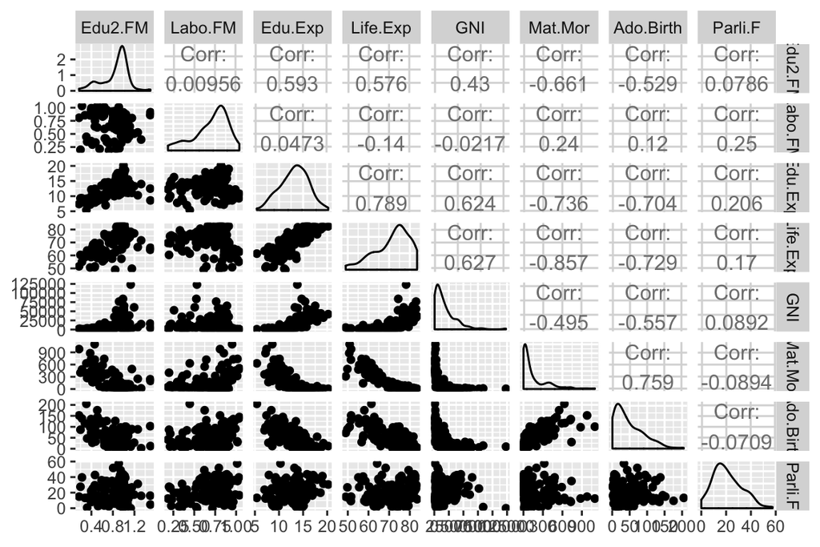

```r
ggpairs(human)
```

Since the variables are not scaled, the means are quite different across variables.

The ggpairs()-plot shows distributions of the variables and shows the correlations between the variables. The first four of the variables (Edu2.FM, Labo.FM, Edu.Exp and Life.Exp) have negative skewness and the remaining four variables are positively skewed.

The corrplot() visualizes correlations between variables:

```r
cor(human)
```

```
##                Edu2.FM      Labo.FM     Edu.Exp   Life.Exp         GNI
## Edu2.FM    1.000000000  0.009564039  0.59325156  0.5760299  0.43030485
## Labo.FM    0.009564039  1.000000000  0.04732183 -0.1400125 -0.02173971
## Edu.Exp    0.593251562  0.047321827  1.00000000  0.7894392  0.62433940
## Life.Exp   0.576029853 -0.140012504  0.78943917  1.0000000  0.62666411
## GNI        0.430304846 -0.021739705  0.62433940  0.6266641  1.00000000
## Mat.Mor   -0.660931770  0.240461075 -0.73570257 -0.8571684 -0.49516234
## Ado.Birth -0.529418415  0.120158862 -0.70356489 -0.7291774 -0.55656208
## Parli.F    0.078635285  0.250232608  0.20608156  0.1700863  0.08920818
##              Mat.Mor  Ado.Birth     Parli.F
## Edu2.FM   -0.6609318 -0.5294184  0.07863528
## Labo.FM    0.2404611  0.1201589  0.25023261
## Edu.Exp   -0.7357026 -0.7035649  0.20608156
## Life.Exp  -0.8571684 -0.7291774  0.17008631
## GNI       -0.4951623 -0.5565621  0.08920818
## Mat.Mor    1.0000000  0.7586615 -0.08944000
## Ado.Birth  0.7586615  1.0000000 -0.07087810
## Parli.F   -0.0894400 -0.0708781  1.00000000
```

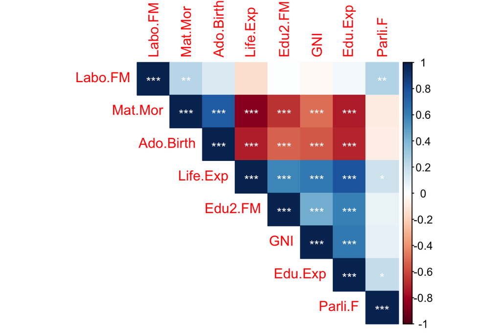

```r
res1 <- cor.mtest(human, conf.level = .95)

cor(human) %>% corrplot(p.mat = res1$p, method = "color", type = "upper",
sig.level = c(.001, .01, .05), pch.cex = .9,
insig = "label_sig", pch.col = "white", order = "AOE")
```

Blue color means positive correlation and red negative correlation. Lighter colors mean weaker association and darker colors stronger.

## 5.2. Principal Component Analysis (PCA) on the non-standardized dataset

Next we will conduct a principal component analysis (PCA) on the not standardized human data and show the variability captured by the principal components. A biplot will be drawn to display the observations by the first two principal components.

```r
# create and print out a summary of pca_human
pca_human <- prcomp(human)
s <- summary(pca_human)
s
```

```
## Importance of components:
##                              PC1      PC2   PC3   PC4   PC5   PC6    PC7
## Standard deviation     1.854e+04 185.5219 25.19 11.45 3.766 1.566 0.1912
## Proportion of Variance 9.999e-01   0.0001  0.00  0.00 0.000 0.000 0.0000
## Cumulative Proportion  9.999e-01   1.0000  1.00  1.00 1.000 1.000 1.0000
##                           PC8
## Standard deviation     0.1591
## Proportion of Variance 0.0000
## Cumulative Proportion  1.0000
```

```r
# rounded percetanges of variance captured by each PC
pca_pr <- 100*round(1*s$importance[2, ], digits = 3)

# print out the percentages of variance
pca_pr
```

```
## PC1 PC2 PC3 PC4 PC5 PC6 PC7 PC8
## 100   0   0   0   0   0   0   0
```

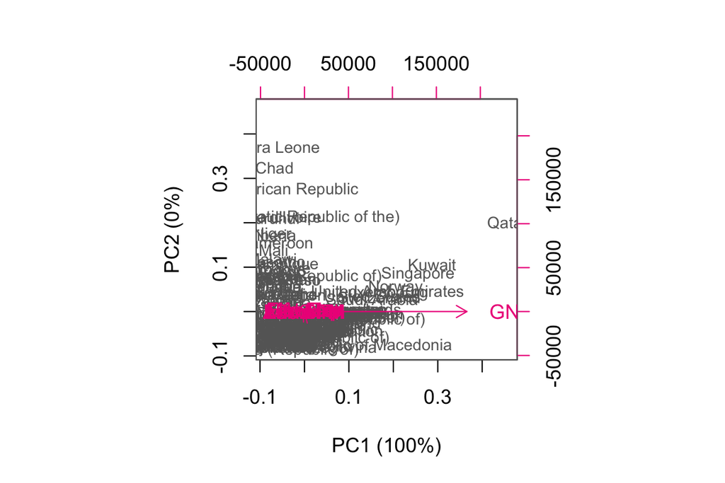

```r
# create object pc_lab to be used as axis labels
pc_lab<-paste0(names(pca_pr), " (", pca_pr, "%)")

# draw a biplot
biplot(pca_human, cex = c(0.8, 1), col = c("grey40", "deeppink2"), xlab = pc_lab[1], ylab = pc_lab[2])
```

## 5.3. Same with standardized data

Let us standardize the data and then perform the PCA again:

```r
# standardize the variables
human_std <- scale(human)

# print out summaries of the standardized variables
summary(human_std)
```

```
##     Edu2.FM           Labo.FM           Edu.Exp           Life.Exp
##  Min.   :-2.8189   Min.   :-2.6247   Min.   :-2.7378   Min.   :-2.7188
##  1st Qu.:-0.5233   1st Qu.:-0.5484   1st Qu.:-0.6782   1st Qu.:-0.6425
##  Median : 0.3503   Median : 0.2316   Median : 0.1140   Median : 0.3056
##  Mean   : 0.0000   Mean   : 0.0000   Mean   : 0.0000   Mean   : 0.0000
##  3rd Qu.: 0.5958   3rd Qu.: 0.7350   3rd Qu.: 0.7126   3rd Qu.: 0.6717
##  Max.   : 2.6646   Max.   : 1.6632   Max.   : 2.4730   Max.   : 1.4218
##       GNI             Mat.Mor          Ado.Birth          Parli.F
##  Min.   :-0.9193   Min.   :-0.6992   Min.   :-1.1325   Min.   :-1.8203
##  1st Qu.:-0.7243   1st Qu.:-0.6496   1st Qu.:-0.8394   1st Qu.:-0.7409
##  Median :-0.3013   Median :-0.4726   Median :-0.3298   Median :-0.1403
##  Mean   : 0.0000   Mean   : 0.0000   Mean   : 0.0000   Mean   : 0.0000
##  3rd Qu.: 0.3712   3rd Qu.: 0.1932   3rd Qu.: 0.6030   3rd Qu.: 0.6127
##  Max.   : 5.6890   Max.   : 4.4899   Max.   : 3.8344   Max.   : 3.1850
```

```r
# create and print out a summary of pca_human
pca_human <- prcomp(human_std)

s <- summary(pca_human)
s
```

```
## Importance of components:
##                           PC1    PC2     PC3     PC4     PC5     PC6
## Standard deviation     2.0708 1.1397 0.87505 0.77886 0.66196 0.53631
## Proportion of Variance 0.5361 0.1624 0.09571 0.07583 0.05477 0.03595
## Cumulative Proportion  0.5361 0.6984 0.79413 0.86996 0.92473 0.96069
##                            PC7     PC8
## Standard deviation     0.45900 0.32224
## Proportion of Variance 0.02634 0.01298
## Cumulative Proportion  0.98702 1.00000
```

```r
# rounded percetanges of variance captured by each PC
pca_pr <- 100*round(1*s$importance[2, ], digits = 3)

# print out the percentages of variance
pca_pr
```

```
##  PC1  PC2  PC3  PC4  PC5  PC6  PC7  PC8
## 53.6 16.2  9.6  7.6  5.5  3.6  2.6  1.3
```

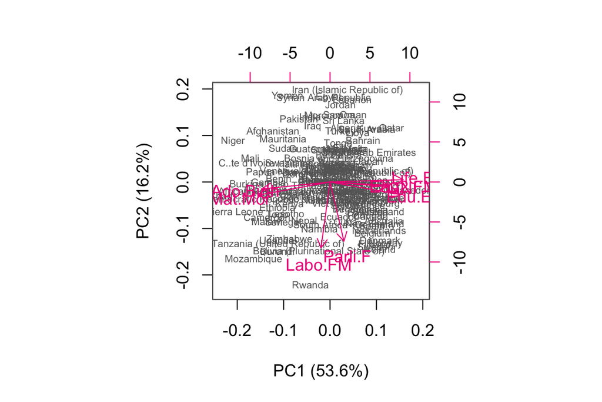

```r
# create object pc_lab to be used as axis labels
pc_lab<-paste0(names(pca_pr), " (", pca_pr, "%)")

# draw a biplot
biplot(pca_human, cex = c(0.6, 1), col = c("grey40", "deeppink2"), xlab = pc_lab[1], ylab = pc_lab[2])
```

Standardizing the data makes a big difference. The results from un-standardized and standardized datas are very different: the results from un-standardized variables showed that PC1 captures all the variation, but with standardized variables PC1 now captures 53,6% (PC2 captures 16,2% and PC3 9,6%).

## 5.4 Personal interpretations

PCA reduces dimensions of a dataset into components that explain the variance in the data. The arrows of the variables can be interpreted so that the PC1 consists of Mat.Mor, Ado.Birth, Edu.Exp, Edu2.FM, Life.Exp and GNI. PC2 consists of Parli.F and Labo.FM. PC1 explains 53,6% of the variance in the data. PC2 explains 16,2% of the variance.

## 5.5 Multiple Correspondence Analysis

The structure and the dimensions of the data:

I picked the variables “breakfast”, “evening”, “sex”, “sugar”, “where”, “lunch” to form my subdata. Here is some information about the structure of the data and some visualizations:

```r
library(FactoMineR)
library(tidyr)
library(dplyr)

data("tea")

tea_mca = tea[, c("breakfast", "evening", "sex", "sugar", "where", "lunch")]

summary(tea_mca)
```

```
##          breakfast          evening    sex          sugar
##  breakfast    :144   evening    :103   F:178   No.sugar:155
##  Not.breakfast:156   Not.evening:197   M:122   sugar   :145
##
##                   where           lunch
##  chain store         :192   lunch    : 44
##  chain store+tea shop: 78   Not.lunch:256
##  tea shop            : 30
```

```r
str(tea_mca)
```

```
## 'data.frame':    300 obs. of  6 variables:
##  $ breakfast: Factor w/ 2 levels "breakfast","Not.breakfast": 1 1 2 2 1 2 1 2 1 1 ...
##  $ evening  : Factor w/ 2 levels "evening","Not.evening": 2 2 1 2 1 2 2 1 2 1 ...
##  $ sex      : Factor w/ 2 levels "F","M": 2 1 1 2 2 2 2 1 2 2 ...
##  $ sugar    : Factor w/ 2 levels "No.sugar","sugar": 2 1 1 2 1 1 1 1 1 1 ...
##  $ where    : Factor w/ 3 levels "chain store",..: 1 1 1 1 1 1 1 1 2 2 ...
##  $ lunch    : Factor w/ 2 levels "lunch","Not.lunch": 2 2 2 2 2 2 2 2 2 2 ...
```

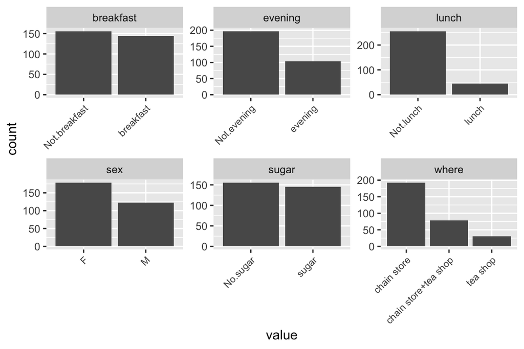

```r
gather(tea_mca) %>% ggplot(aes(value)) + facet_wrap("key", scales = "free") +geom_bar()+theme(axis.text.x = element_text(angle = 45, hjust = 1, size = 8))
```

The dataset tea_mca consists of 300 observations of 6 variables.

## MCA:

```r
mca <- MCA(tea_mca, graph = FALSE)

summary(mca)
```

```
##
## Call:
## MCA(X = tea_mca, graph = FALSE)
##
##
## Eigenvalues
##                        Dim.1   Dim.2   Dim.3   Dim.4   Dim.5   Dim.6
## Variance               0.216   0.198   0.178   0.171   0.154   0.132
## % of var.             18.552  16.987  15.288  14.679  13.222  11.317
## Cumulative % of var.  18.552  35.538  50.827  65.506  78.727  90.045
##                        Dim.7
## Variance               0.116
## % of var.              9.955
## Cumulative % of var. 100.000
##
## Individuals (the 10 first)
##                         Dim.1    ctr   cos2    Dim.2    ctr   cos2
## 1                    |  0.408  0.257  0.206 | -0.315  0.167  0.122 |
## 2                    | -0.567  0.495  0.487 | -0.272  0.124  0.112 |
## 3                    | -0.095  0.014  0.010 |  0.194  0.063  0.043 |
## 4                    |  0.601  0.556  0.460 | -0.364  0.223  0.169 |
## 5                    |  0.203  0.063  0.040 |  0.089  0.013  0.008 |
## 6                    |  0.116  0.021  0.018 | -0.475  0.379  0.296 |
## 7                    | -0.077  0.009  0.007 | -0.426  0.305  0.230 |
## 8                    | -0.095  0.014  0.010 |  0.194  0.063  0.043 |
## 9                    | -0.371  0.212  0.117 | -0.221  0.082  0.042 |
## 10                   | -0.091  0.013  0.006 |  0.294  0.145  0.062 |
##                       Dim.3    ctr   cos2
## 1                     0.447  0.373  0.246 |
## 2                     0.028  0.001  0.001 |
## 3                    -0.740  1.022  0.632 |
## 4                    -0.153  0.044  0.030 |
## 5                     0.218  0.089  0.046 |
## 6                    -0.214  0.086  0.060 |
## 7                     0.386  0.278  0.188 |
## 8                    -0.740  1.022  0.632 |
## 9                     0.712  0.948  0.434 |
## 10                    0.544  0.554  0.211 |
##
## Categories (the 10 first)
```

[output cut: 16 more lines]

```
## F                      0.041   3.493 |  -0.368   7.526   0.198  -7.695 |
## M                      0.041  -3.493 |   0.538  10.981   0.198   7.695 |
## No.sugar               0.022  -2.561 |  -0.075   0.270   0.006  -1.338 |
## sugar                  0.022   2.561 |   0.080   0.289   0.006   1.338 |
## chain store            0.004  -1.050 |  -0.327   6.398   0.190  -7.541 |
## chain store+tea shop   0.089   5.147 |   0.500   6.081   0.088   5.128 |
##
## Categorical variables (eta2)
##                        Dim.1 Dim.2 Dim.3
## breakfast            | 0.072 0.004 0.577 |
## evening              | 0.137 0.426 0.041 |
## sex                  | 0.452 0.041 0.198 |
## sugar                | 0.458 0.022 0.006 |
## where                | 0.178 0.170 0.196 |
## lunch                | 0.001 0.526 0.052 |
```

The summary of the MCA lists the explained variances. The first dimension explains 18,55% of the variance the second dimension explains 16,99%, the third 15,29%.

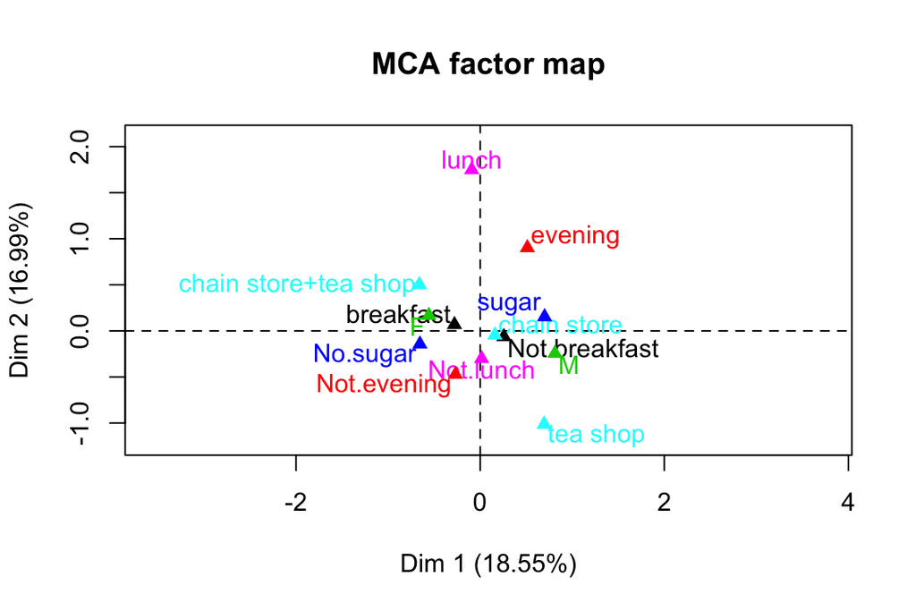

```r
plot(mca, invisible=c("ind"), habillage="quali")
```

# 6: Analysis of longitudinal data

This week’s tasks focus on analysis of longitudinal data. Analysis will be conducted on two datasets in the way presented in chapters 8 and 9 from the book “Multivariate Analysis for the Behavioral Sciences”.

The datasets have been wrangled from wide form to long form before analysis. The R script file that created the data files can be viewed [here](https://github.com/MikkoPatronen/IODS-project/blob/master/data/meet_and_repeat.R).

```r
rm(list=ls())
setwd("~/Library/Mobile Documents/com~apple~CloudDocs/Documents/GitHub/IODS-project/data")

library(dplyr)
library(stringr)
library(ggplot2)
library(GGally)
library(tidyr)
library(readr)
library(lme4)
RATSL <- read.table("RATSL.txt")
BPRSL <- read.table("BPRSL.txt")

RATSL$ID <- factor(RATSL$ID)
RATSL$Group <- factor(RATSL$Group)
BPRSL$treatment <- factor(BPRSL$treatment)
BPRSL$subject <- factor(BPRSL$subject)
```

## 6.1: Implement the analyses of chapter 8 of MABS using the RATS data

The RATS data consists of three groups of rats. There are 16 rats in total. The groups were exposed to different diets and their weight in grams were measured weekly for nine weeks. The dimensions (rows and columns) of the RATS data are:

```r
dim(RATSL)
```

```
## [1] 176   5
```

Let us visualize the weight increase of the rats by groups:

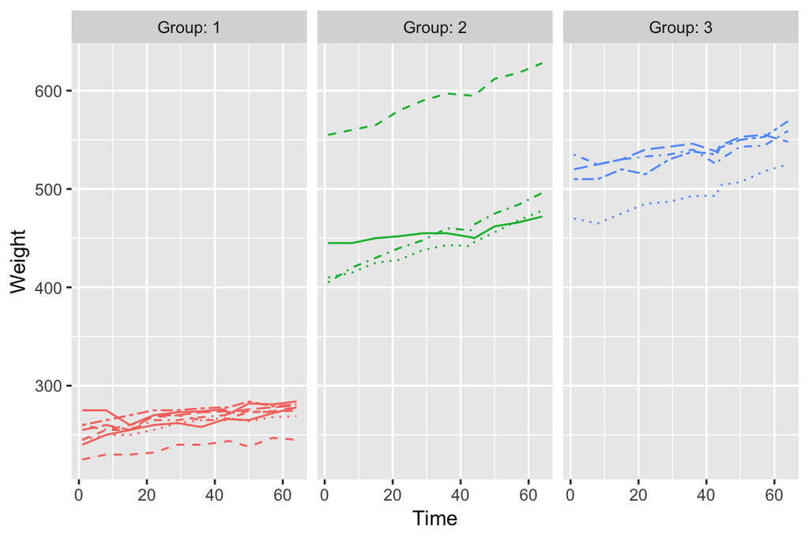

```r
ggplot(RATSL, aes(x = Time, y = Weight, linetype = ID, col = Group)) +
geom_line() +
scale_linetype_manual(values = rep(1:10, times=4)) +
facet_grid(. ~ Group, labeller = label_both) +
theme(legend.position = "none") +
scale_y_continuous(name = "Weight", limits = c(min(RATSL$Weight), max(RATSL$Weight)))
```

From the graph we can see that the rat weights seem to increase in all groups over time. There is also one big rat in group 2 that is much heavier than other rats in that group. In groups 2 and 3 the weight seem to have increased more than in group 1. Let us standardize the values to make the groups easier to compare, and plot the standardized data:

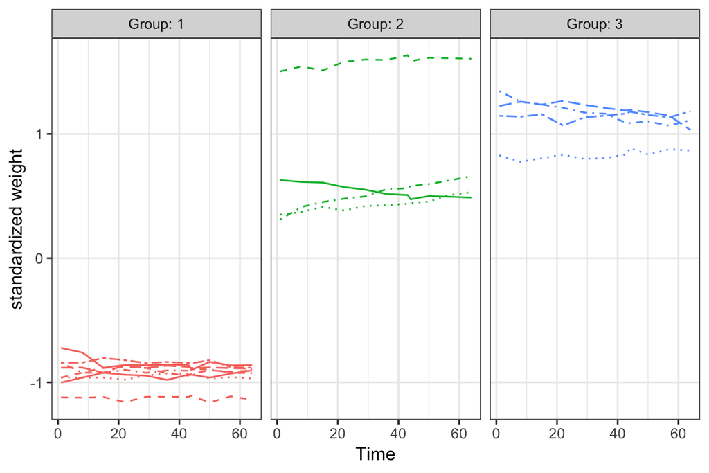

```r
RATSL <- RATSL %>%
group_by(Time) %>%
mutate(stdWeight = (Weight-mean(Weight))/sd(Weight)) %>%
ungroup()

p1 <- ggplot(RATSL, aes(x = Time, y = stdWeight, linetype = ID, col = Group))
p2 <- p1 + geom_line() + scale_linetype_manual(values = rep(1:10, times=4))
p3 <- p2 + facet_grid(. ~ Group, labeller = label_both)
p4 <- p3 + theme_bw() + theme(legend.position = "none")
p5 <- p4 + theme(panel.grid.minor.y = element_blank())
p6 <- p5 + scale_y_continuous(name = "standardized weight")
p6
```

There does not seem to be huge differences in weight changes between groups. The same information can be seen from different visualization below, where the plot is built based on means and standard errors:

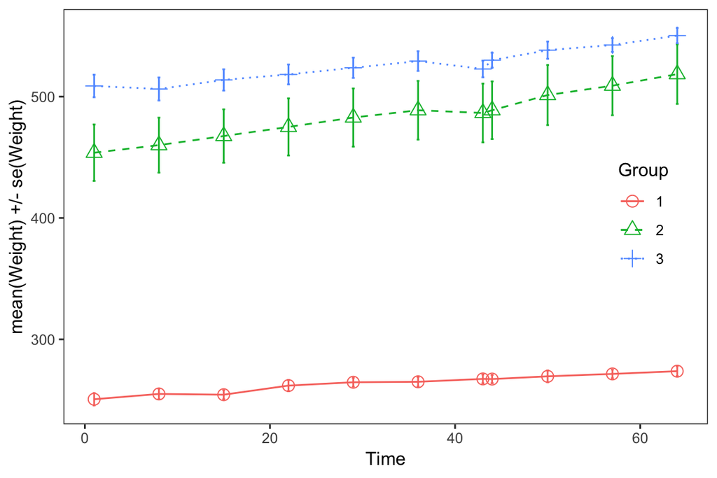

```r
n <- length(0:8) # Time, incl. baseline (0)
RATSS <- RATSL %>%
group_by(Group, Time) %>%
summarise( mean=mean(Weight), se=sd(Weight)/sqrt(n) ) %>%
ungroup()

p1 <- ggplot(RATSS, aes(x = Time, y = mean, linetype = Group, shape = Group, col = Group))
p2 <- p1 + geom_line() + scale_linetype_manual(values = c(1,2,3))
p3 <- p2 + geom_point(size=3) + scale_shape_manual(values = c(1,2,3))
p4 <- p3 + geom_errorbar(aes(ymin=mean-se, ymax=mean+se, linetype="1"), width=0.3)
p5 <- p4 + theme_bw() + theme(panel.grid.major = element_blank(), panel.grid.minor = element_blank())
p6 <- p5 + theme(legend.position = c(0.9,0.5))
p7 <- p6 + scale_y_continuous(name = "mean(Weight) +/- se(Weight)")
p7
```

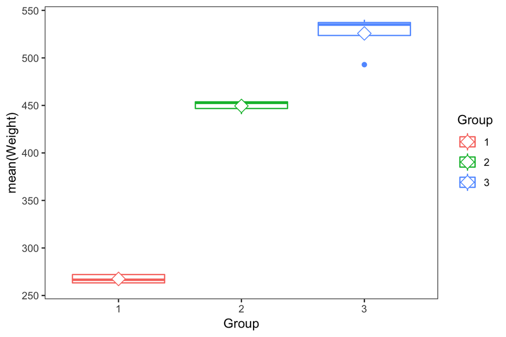

```r
RATSLB <- RATSL %>%
filter(Time> 0) %>%
group_by(Group, ID) %>%
summarise( mean=mean(Weight) ) %>%
ungroup()

# Remove the big rat:
RATSLB1 <- RATSLB %>%
filter(mean < 550)

RATSLB2 <- RATSLB1 %>%
filter(mean > 250)

p1 <- ggplot(RATSLB2, aes(x = Group, y = mean, outline=FALSE, col = Group))
p2 <- p1 + geom_boxplot(outline=FALSE)
p3 <- p2 + theme_bw() + theme(panel.grid.major = element_blank(), panel.grid.minor = element_blank())
p4 <- p3 + stat_summary(fun.y = "mean", geom = "point", shape=23, size=4, fill = "white")
p5 <- p4 + scale_y_continuous(name = "mean(Weight)")
p5
```

All the groups have different means. Now we must conduct analysis of variance (ANOVA) to study whether the differences between groups are statistically significant. In this test the null hypothesis is that the group means do not differ.

```r
res.aov <- aov(mean ~ Group, data = RATSLB2)
summary(res.aov)
```

```
##             Df Sum Sq Mean Sq F value   Pr(>F)
## Group        2 188182   94091   580.4 7.07e-12 ***
## Residuals   11   1783     162
## ---
## Signif. codes:  0 '***' 0.001 '**' 0.01 '*' 0.05 '.' 0.1 ' ' 1
```

According to the ANOVA test the p-value is close to zero. Therefore we can infer that the groups differ in group means.

## 6.2: Implement the analyses of chapter 9 of MABS using the BPRS data

The BPRS data consists of 40 male subjects that were divided into two groups that received different treatments. All subjects were rated on BPRS (brief psychiatric rating scale) for 8 weeks in total. The scale evaluates schizophrenia among the patients. The dimensions of the dataset (rows and columns) are

```r
dim(BPRSL)
```

```
## [1] 360   5
```

Here is a plot of the two groups showing changes among individuals through eight weeks:

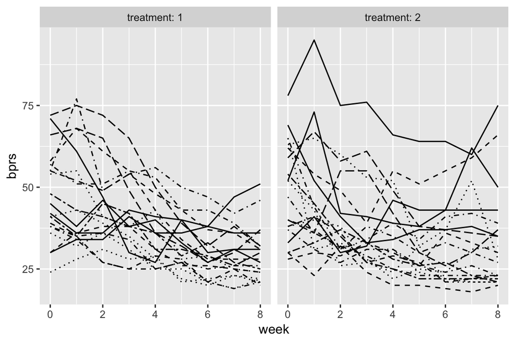

```r
ggplot(BPRSL, aes(x = week, y = bprs, linetype = subject)) +
geom_line() +
scale_linetype_manual(values = rep(1:10, times=4)) +
facet_grid(. ~ treatment, labeller = label_both) +
theme(legend.position = "none") +
scale_y_continuous(limits = c(min(BPRSL$bprs), max(BPRSL$bprs)))
```